# Calculation errors

Calculation errors

*A collection of common [dataviz caveats](https://www.data-to-viz.com/caveats.html) by [Data-to-Viz.com](https://www.data-to-viz.com)*

[figure not shown]

This is probably the most obvious pitfall example of the collection, but is probably the most frequent one as well. Number inconsistencies on a graphic make it completely useless.

# Percentages don’t add up to 100%

For example, when displaying percentages on a pie chart, double-check that the percents sum to 100%:

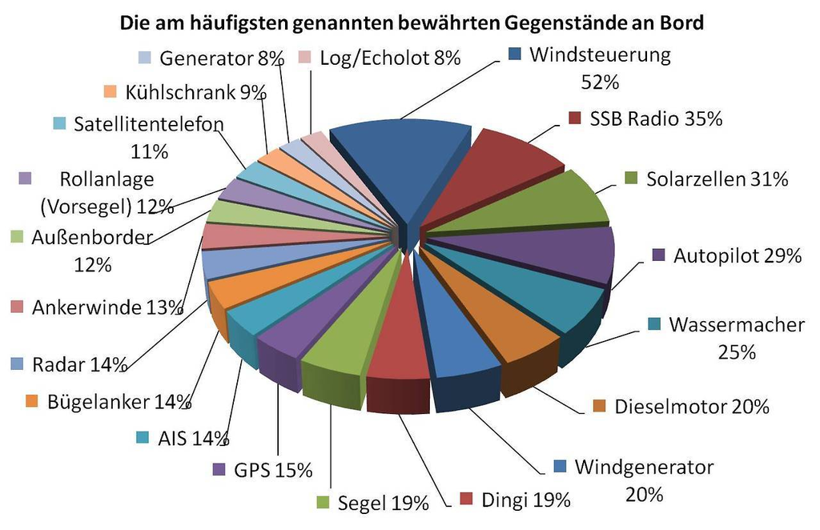

Source: [WTF Visualizations](http://viz.wtf/post/162907112938/i-guess-its-best-to-show-all-the-data-and-use-a#notes)

Here, alsoe note that using an exploded 3D pie chart is probably the worst way to convey information ever invented. ([Read more about it](http://www.data-to-viz.com/caveat/pie.html))

# Values don’t match visuals

In the following example, the 45% annotation is linked with the biggest part of the donut chart; clearly something is incorrect.

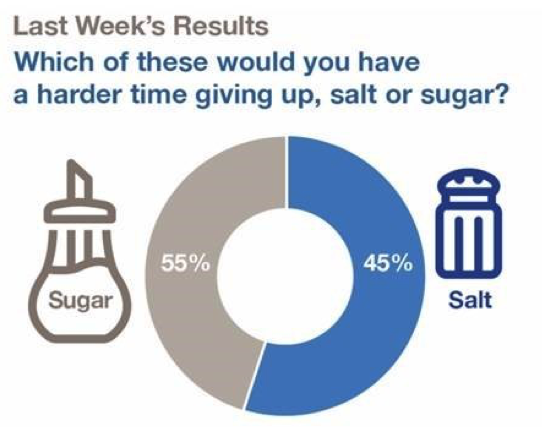

Source: [WTF Visualizations](http://viz.wtf/post/169392205697/fewer-people-would-have-a-hard-time-giving-up)

# Going further

- On a daily basis, the website [WTF Visualization](http://viz.wtf) shows visualizations that make no sense. Check it out or follow them on [twitter](https://twitter.com/WTFViz).

# Comments

Any thoughts on this? Found any mistake? Disagree? Please drop me a word on [twitter](https://twitter.com/R_Graph_Gallery) or in the comment section below:

A work by [Yan Holtz](https://github.com/holtzy/) for data-to-viz.com